# Rentabilidad de grandes eventos deportivos en el contexto de los países BRICS

Rodrigo Minguito Linaje

30 de Noviembre de 2018

## Human Development Index

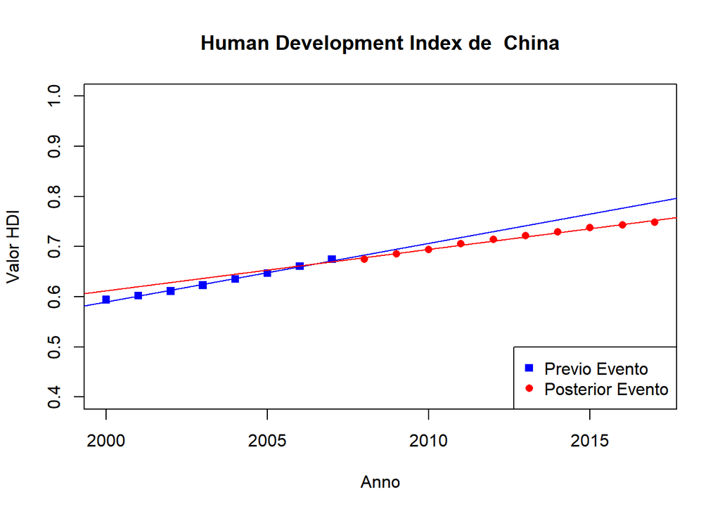

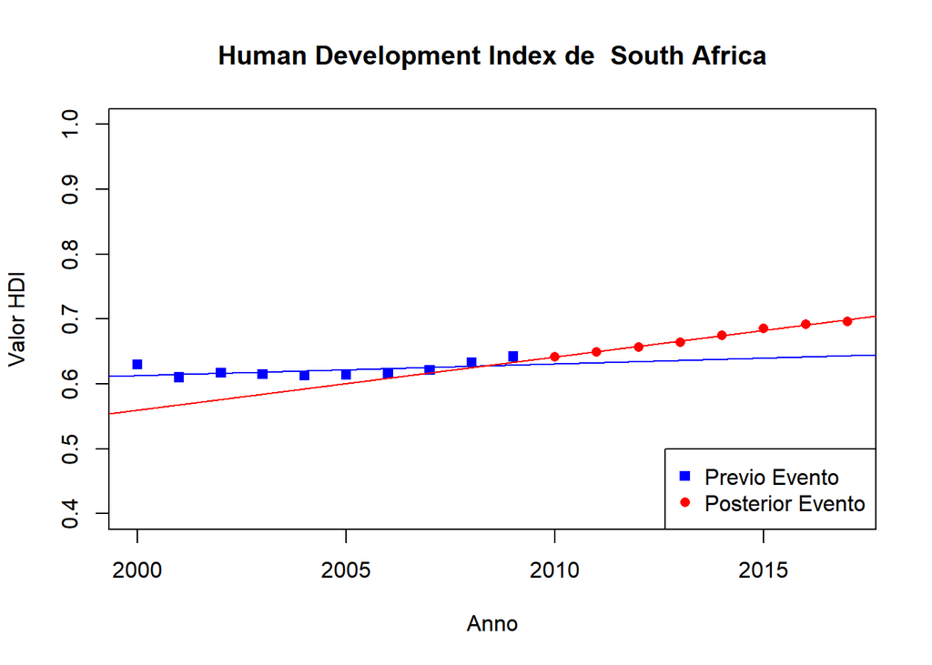

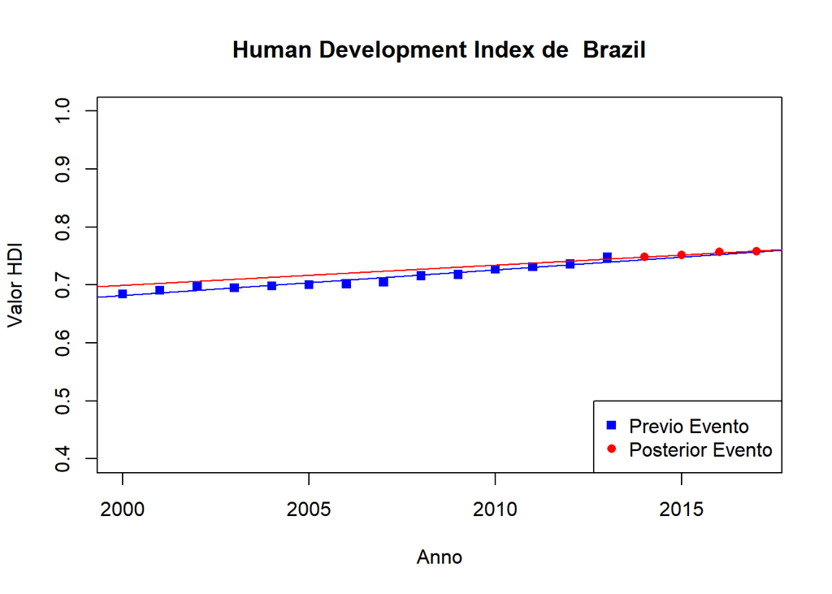

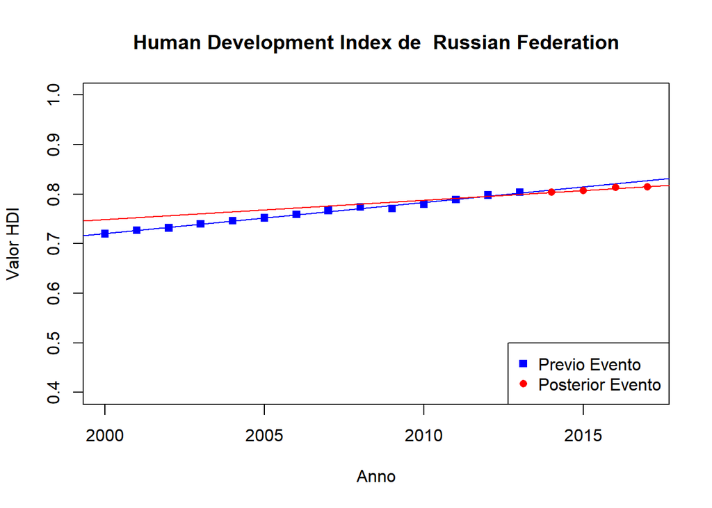

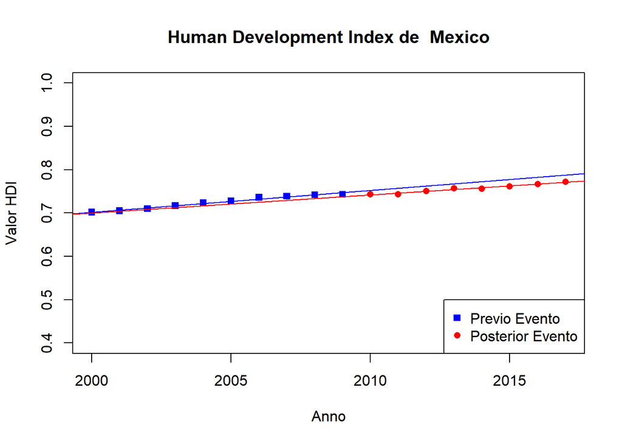

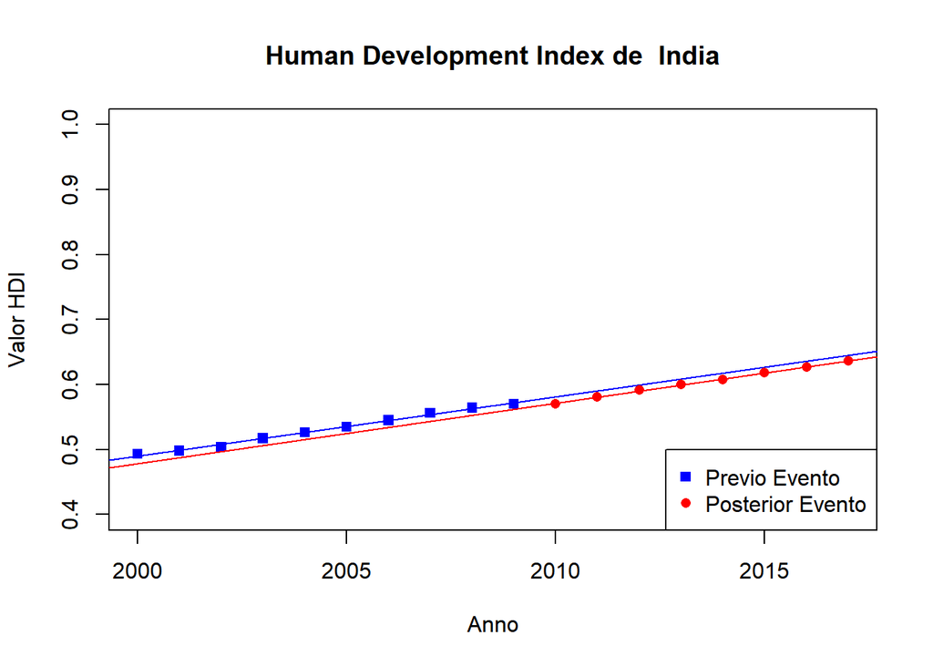

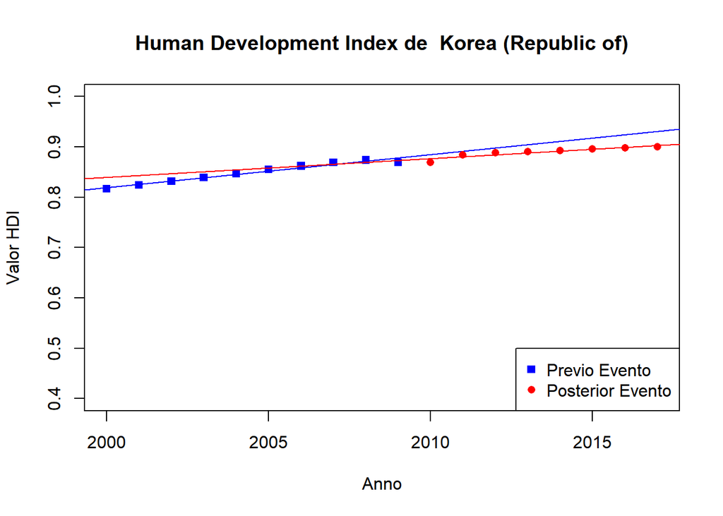

## Global Peace Index

No hay datos para China ya que el GPI se obtiene solo desde 2008, y para Sudáfrica solo hay dos valores previos, lo que desvirtua el gráfico.

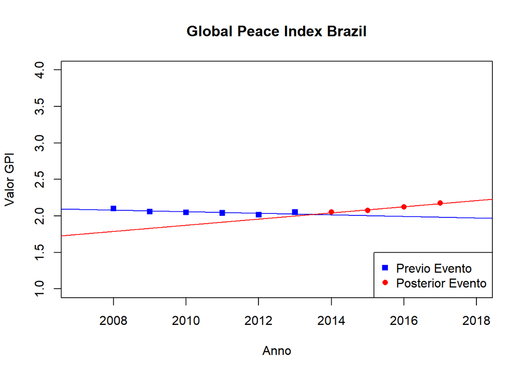

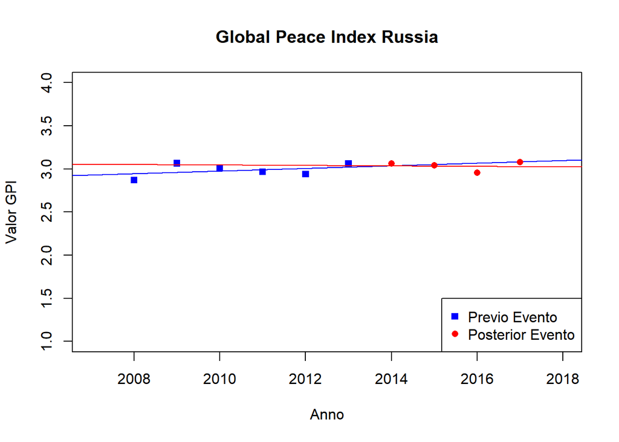

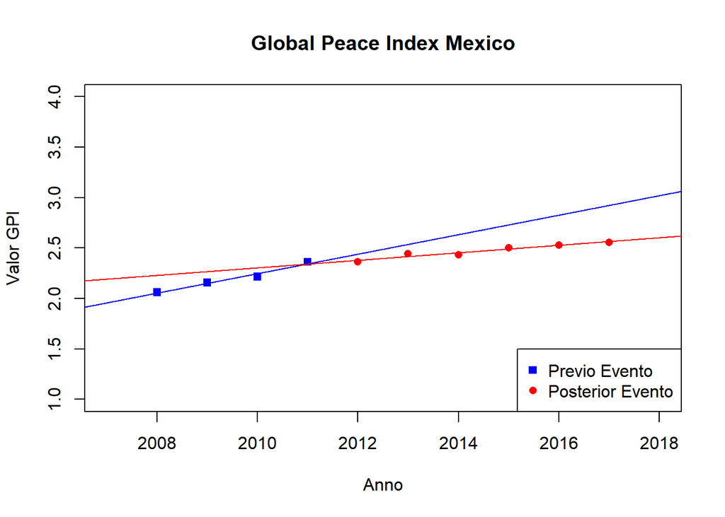

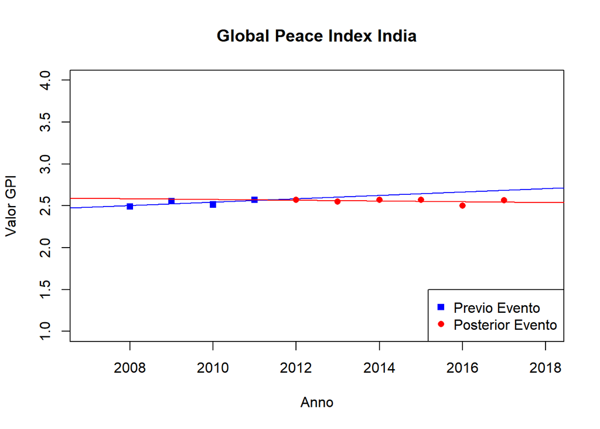

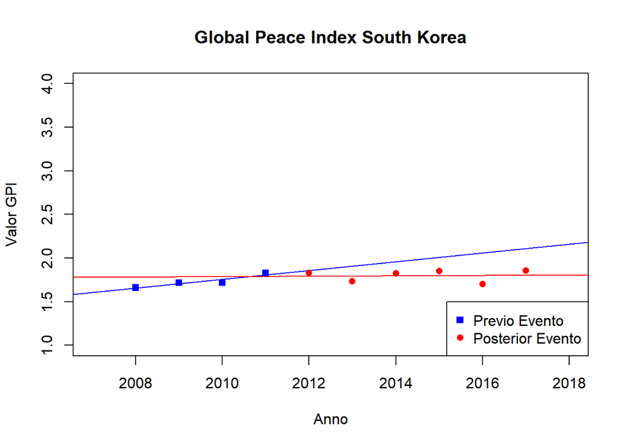

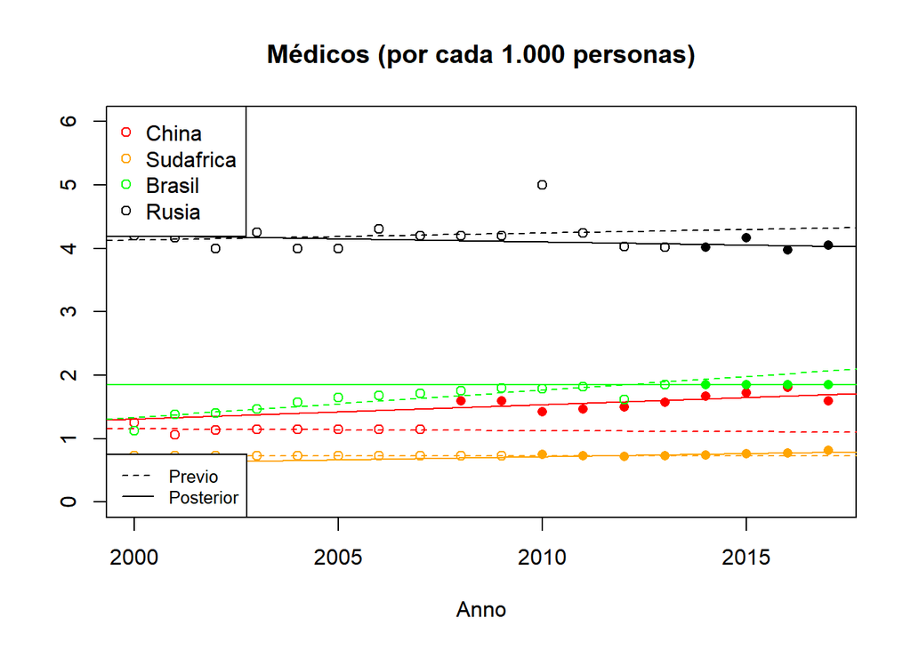

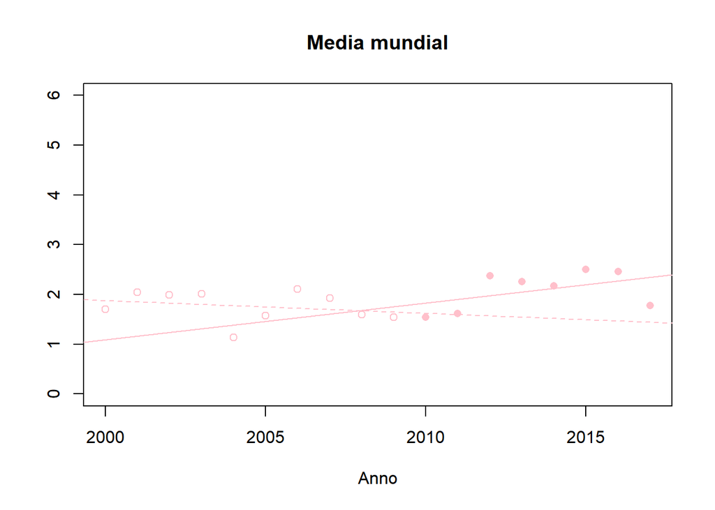

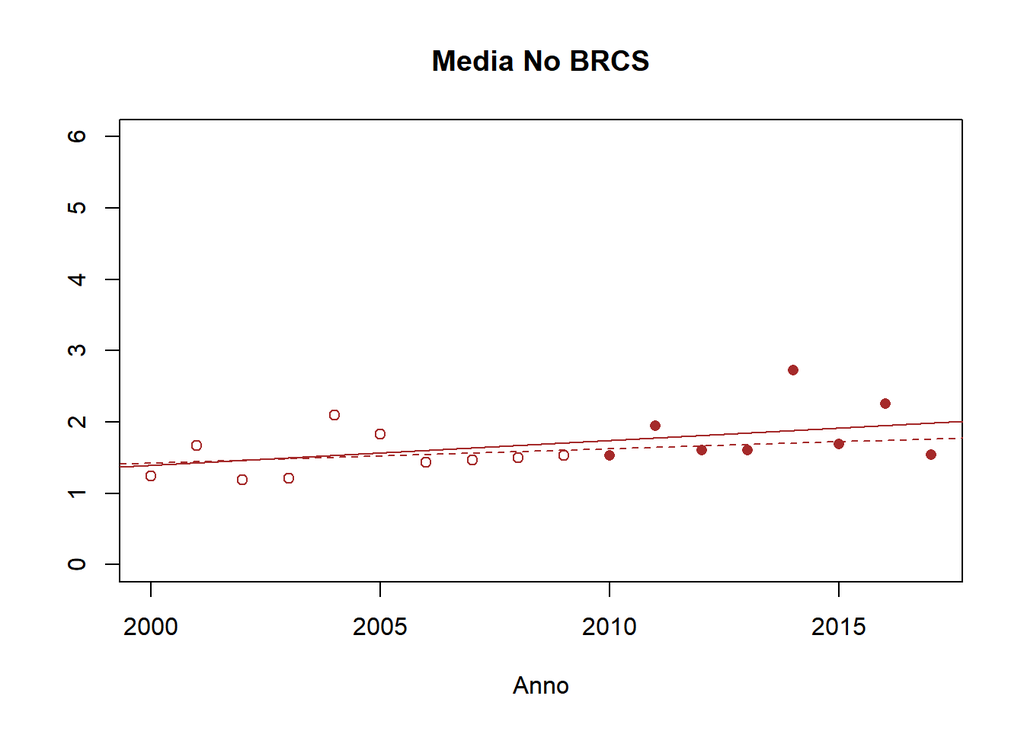

**Coeficientes de Correlacion - Médicos (por cada 1.000 personas)**

| China |  |  |
| --- | --- | --- |
| Tendencia | 2000 - 2008 | NEG |
| Correlación con Promedio mundial | 2000 - 2008 | -0.286 |
| Correlación con Promedio no BRCS | 2000 - 2008 | -0.313 |
| Tendencia | 2008 - 2017 | POS |
| Correlación con Promedio mundial | 2008 - 2017 | 0.785 |
| Correlación con Promedio no BRCS | 2008 - 2017 | 0.359 |
| Sudafrica |  |  |
| Tendencia | 2000 - 2010 | NEG |
| Correlación con Promedio mundial | 2000 - 2010 | NA |
| Correlación con Promedio no BRCS | 2000 - 2010 | NA |
| Tendencia | 2010 - 2017 | POS |
| Correlación con Promedio mundial | 2010 - 2017 | 0.568 |
| Correlación con Promedio no BRCS | 2010 - 2017 | 0.424 |
| Brasil |  |  |
| Tendencia | 2000 - 2014 | POS |
| Correlación con Promedio mundial | 2000 - 2014 | 0.08 |
| Correlación con Promedio no BRCS | 2000 - 2014 | 0.518 |
| Tendencia | 2014 - 2017 | — |
| Correlación con Promedio mundial | 2014 - 2017 | NA |
| Correlación con Promedio no BRCS | 2014 - 2017 | NA |
| Rusia |  |  |
| Tendencia | 2000 - 2014 | POS |
| Correlación con Promedio mundial | 2000 - 2014 | -0.082 |
| Correlación con Promedio no BRCS | 2000 - 2014 | -0.021 |
| Tendencia | 2014 - 2017 | NEG |
| Correlación con Promedio mundial | 2014 - 2017 | -0.741 |
| Correlación con Promedio no BRCS | 2014 - 2017 | 0.926 |

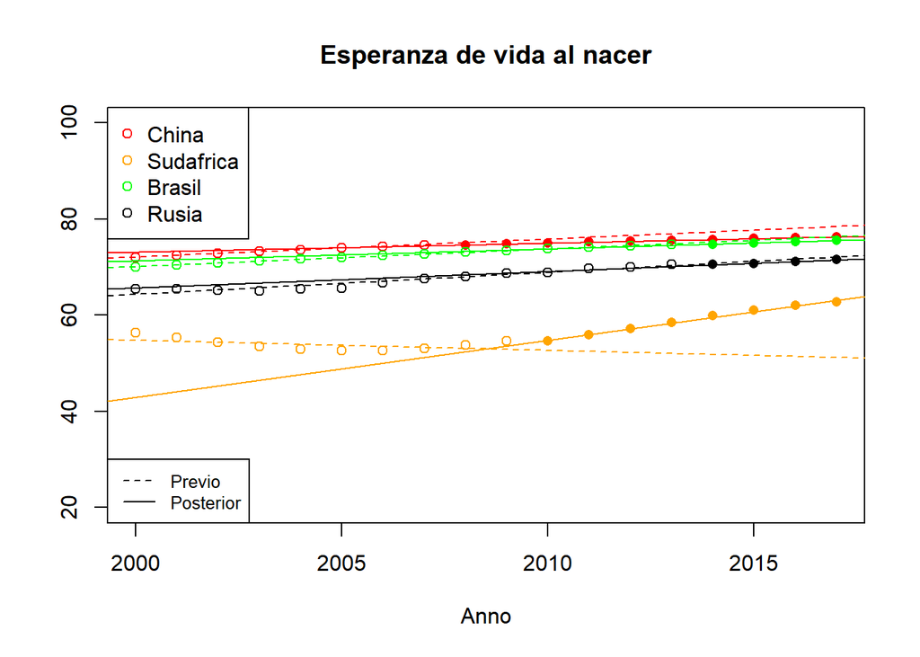

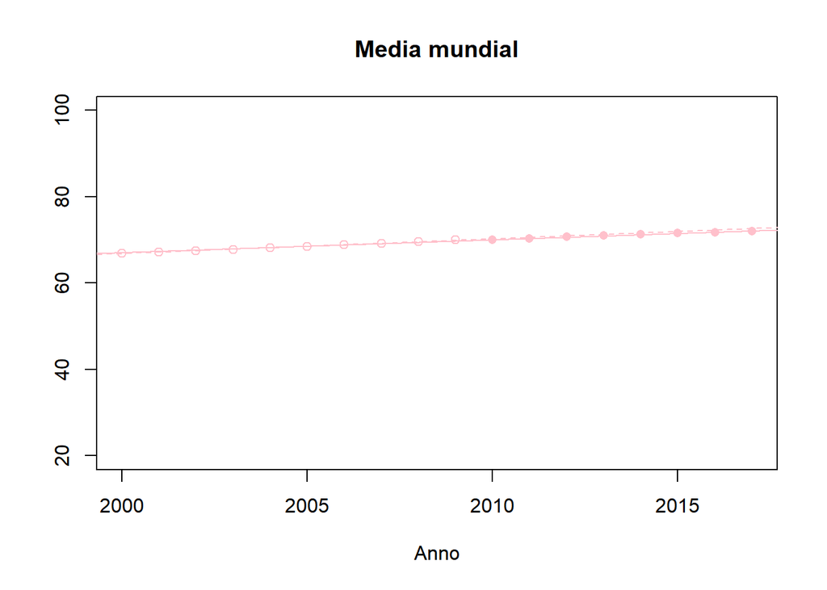

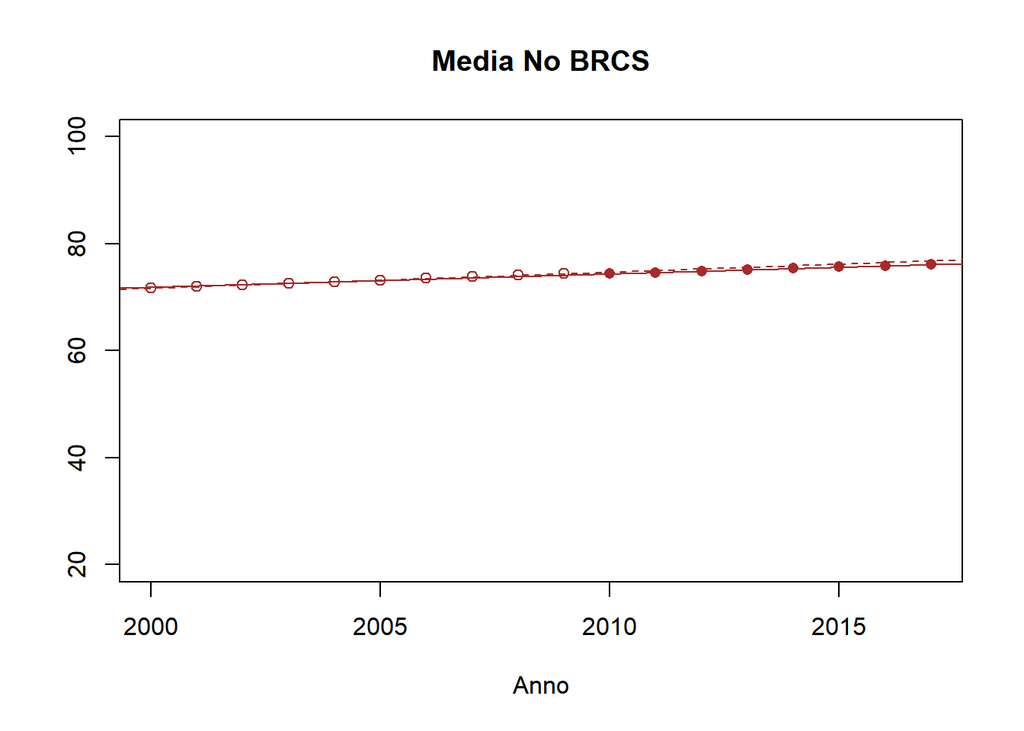

**Coeficientes de Correlacion - Esperanza de vida al nacer**

| China |  |  |
| --- | --- | --- |
| Tendencia | 2000 - 2008 | POS |
| Correlación con Promedio mundial | 2000 - 2008 | 0.99 |
| Correlación con Promedio no BRCS | 2000 - 2008 | 0.997 |
| Tendencia | 2008 - 2017 | POS |
| Correlación con Promedio mundial | 2008 - 2017 | 0.999 |
| Correlación con Promedio no BRCS | 2008 - 2017 | 0.998 |
| Sudafrica |  |  |
| Tendencia | 2000 - 2010 | NEG |
| Correlación con Promedio mundial | 2000 - 2010 | -0.468 |
| Correlación con Promedio no BRCS | 2000 - 2010 | -0.522 |
| Tendencia | 2010 - 2017 | POS |
| Correlación con Promedio mundial | 2010 - 2017 | 0.999 |
| Correlación con Promedio no BRCS | 2010 - 2017 | 0.997 |
| Brasil |  |  |
| Tendencia | 2000 - 2014 | POS |
| Correlación con Promedio mundial | 2000 - 2014 | 0.998 |
| Correlación con Promedio no BRCS | 2000 - 2014 | 1 |
| Tendencia | 2014 - 2017 | POS |
| Correlación con Promedio mundial | 2014 - 2017 | 0.996 |
| Correlación con Promedio no BRCS | 2014 - 2017 | 1 |
| Rusia |  |  |
| Tendencia | 2000 - 2014 | POS |
| Correlación con Promedio mundial | 2000 - 2014 | 0.967 |
| Correlación con Promedio no BRCS | 2000 - 2014 | 0.953 |
| Tendencia | 2014 - 2017 | POS |
| Correlación con Promedio mundial | 2014 - 2017 | 0.979 |
| Correlación con Promedio no BRCS | 2014 - 2017 | 0.977 |

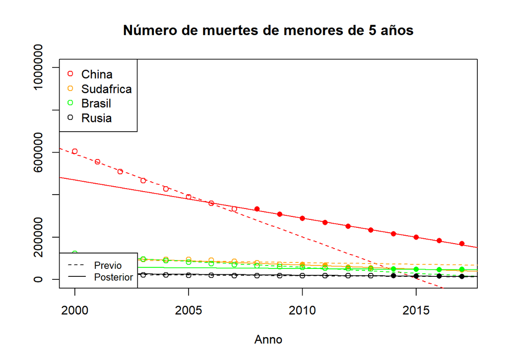

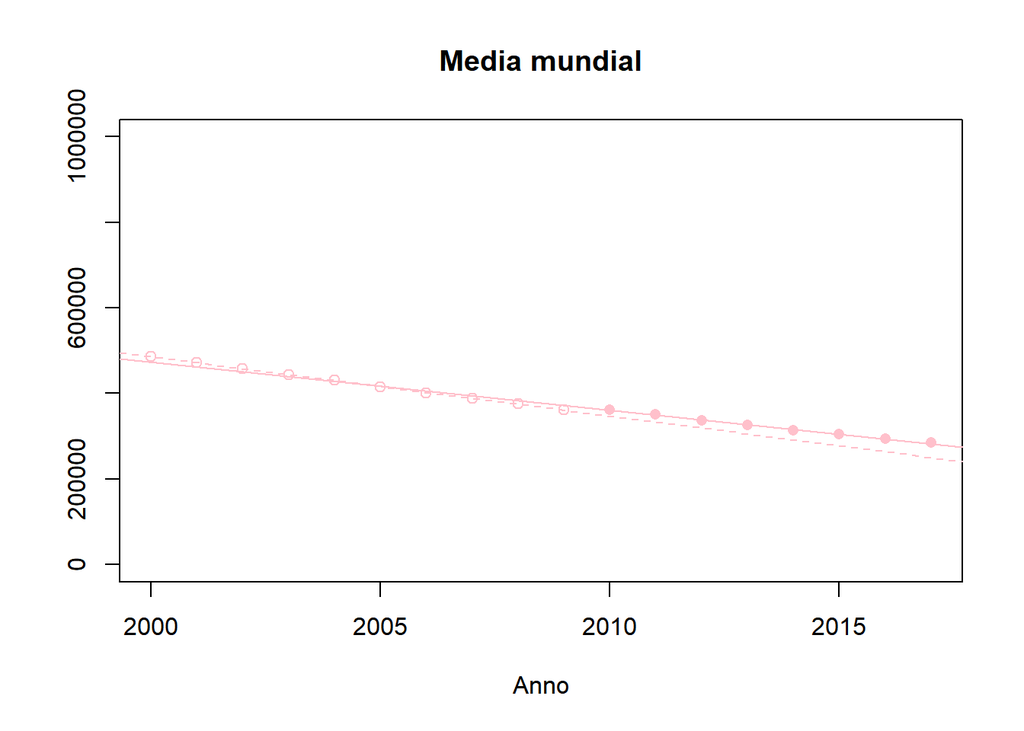

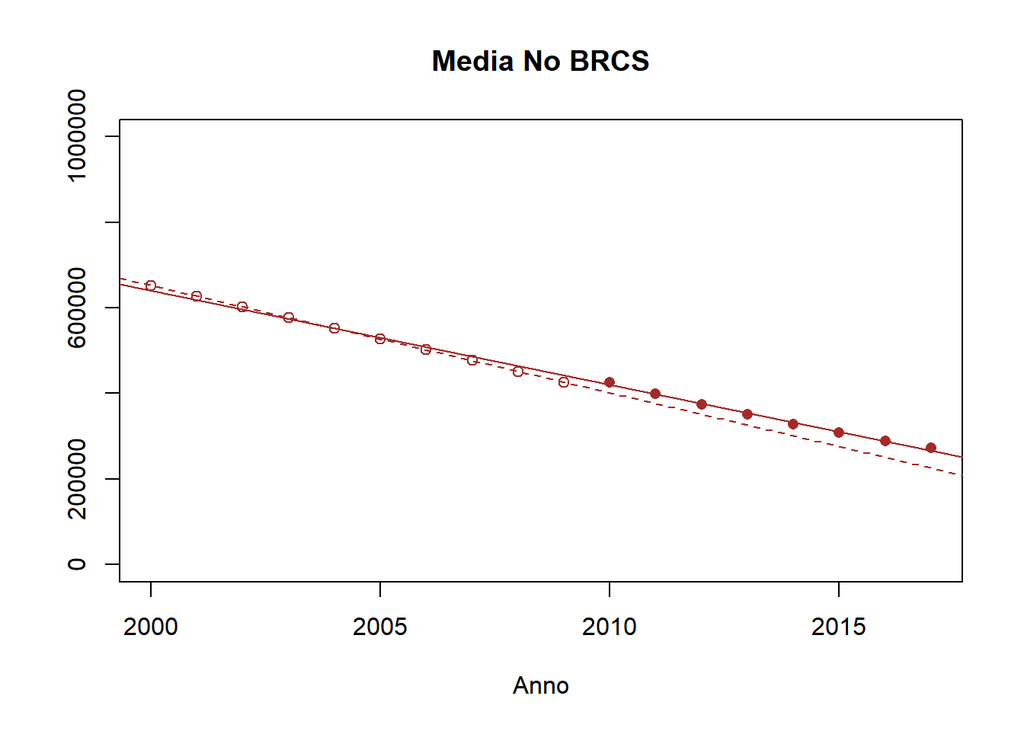

**Coeficientes de Correlacion - Número de muertes de menores de 5 años**

| China |  |  |
| --- | --- | --- |
| Tendencia | 2000 - 2008 | NEG |
| Correlación con Promedio mundial | 2000 - 2008 | 0.996 |
| Correlación con Promedio no BRCS | 2000 - 2008 | 0.995 |
| Tendencia | 2008 - 2017 | NEG |
| Correlación con Promedio mundial | 2008 - 2017 | 0.999 |
| Correlación con Promedio no BRCS | 2008 - 2017 | 0.999 |
| Sudafrica |  |  |
| Tendencia | 2000 - 2010 | NEG |
| Correlación con Promedio mundial | 2000 - 2010 | 0.581 |
| Correlación con Promedio no BRCS | 2000 - 2010 | 0.603 |
| Tendencia | 2010 - 2017 | NEG |
| Correlación con Promedio mundial | 2010 - 2017 | 0.973 |
| Correlación con Promedio no BRCS | 2010 - 2017 | 0.978 |
| Brasil |  |  |
| Tendencia | 2000 - 2014 | NEG |
| Correlación con Promedio mundial | 2000 - 2014 | 0.982 |
| Correlación con Promedio no BRCS | 2000 - 2014 | 0.976 |
| Tendencia | 2014 - 2017 | NEG |
| Correlación con Promedio mundial | 2014 - 2017 | 0.712 |
| Correlación con Promedio no BRCS | 2014 - 2017 | 0.723 |
| Rusia |  |  |
| Tendencia | 2000 - 2014 | NEG |
| Correlación con Promedio mundial | 2000 - 2014 | 0.957 |
| Correlación con Promedio no BRCS | 2000 - 2014 | 0.948 |
| Tendencia | 2014 - 2017 | NEG |
| Correlación con Promedio mundial | 2014 - 2017 | 0.992 |
| Correlación con Promedio no BRCS | 2014 - 2017 | 0.99 |

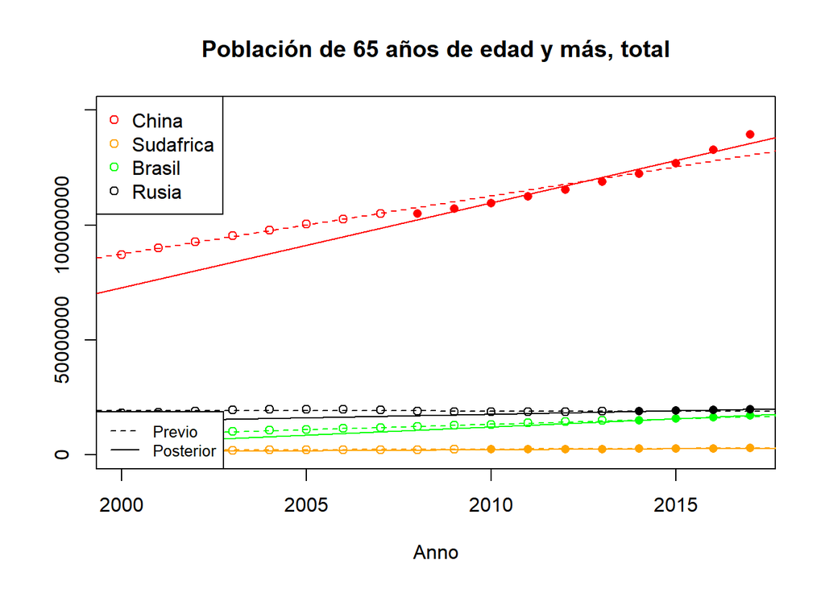

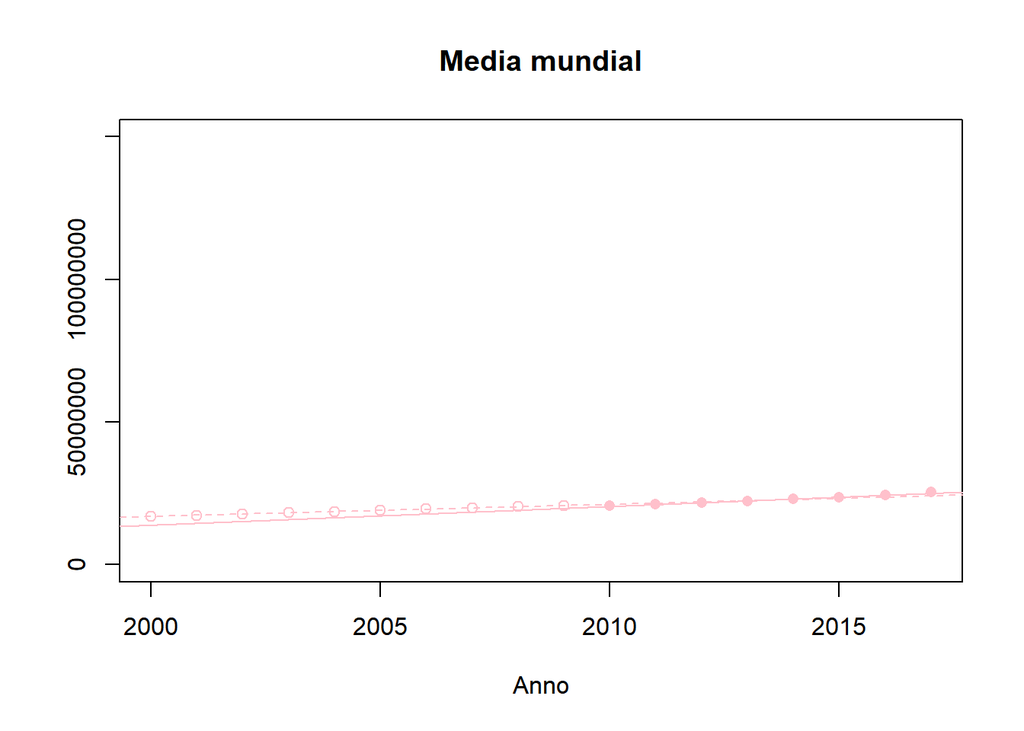

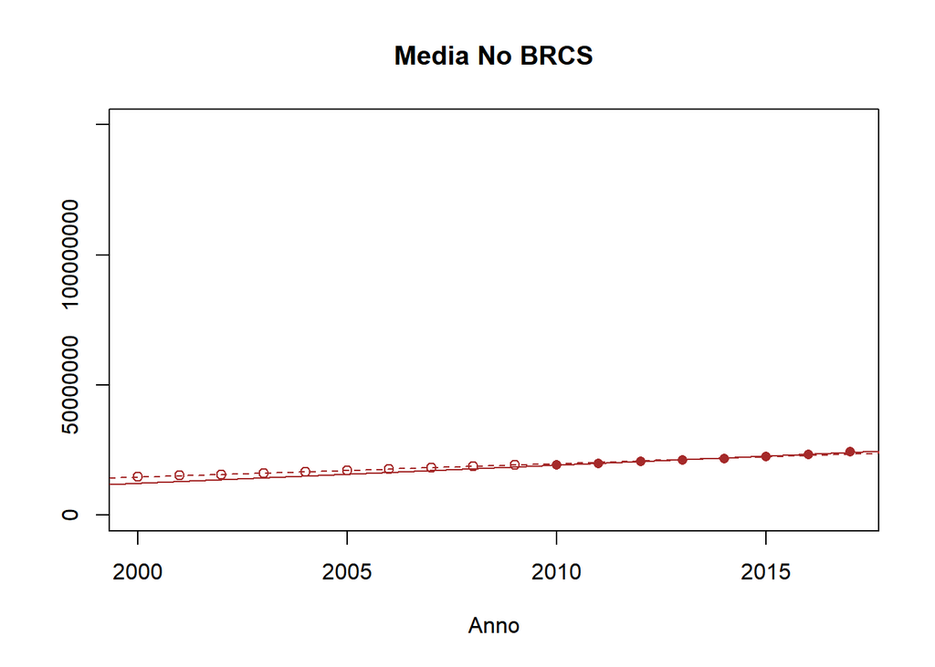

**Coeficientes de Correlacion - Población de 65 años de edad y más, total**

| China |  |  |
| --- | --- | --- |
| Tendencia | 2000 - 2008 | POS |
| Correlación con Promedio mundial | 2000 - 2008 | 1 |
| Correlación con Promedio no BRCS | 2000 - 2008 | 0.999 |
| Tendencia | 2008 - 2017 | POS |
| Correlación con Promedio mundial | 2008 - 2017 | 0.997 |
| Correlación con Promedio no BRCS | 2008 - 2017 | 0.994 |
| Sudafrica |  |  |
| Tendencia | 2000 - 2010 | POS |
| Correlación con Promedio mundial | 2000 - 2010 | 0.999 |
| Correlación con Promedio no BRCS | 2000 - 2010 | 1 |
| Tendencia | 2010 - 2017 | POS |
| Correlación con Promedio mundial | 2010 - 2017 | 1 |
| Correlación con Promedio no BRCS | 2010 - 2017 | 1 |
| Brasil |  |  |
| Tendencia | 2000 - 2014 | POS |
| Correlación con Promedio mundial | 2000 - 2014 | 1 |
| Correlación con Promedio no BRCS | 2000 - 2014 | 1 |
| Tendencia | 2014 - 2017 | POS |
| Correlación con Promedio mundial | 2014 - 2017 | 1 |
| Correlación con Promedio no BRCS | 2014 - 2017 | 1 |
| Rusia |  |  |
| Tendencia | 2000 - 2014 | NEG |
| Correlación con Promedio mundial | 2000 - 2014 | -0.079 |
| Correlación con Promedio no BRCS | 2000 - 2014 | -0.1 |
| Tendencia | 2014 - 2017 | POS |
| Correlación con Promedio mundial | 2014 - 2017 | 0.987 |
| Correlación con Promedio no BRCS | 2014 - 2017 | 0.987 |

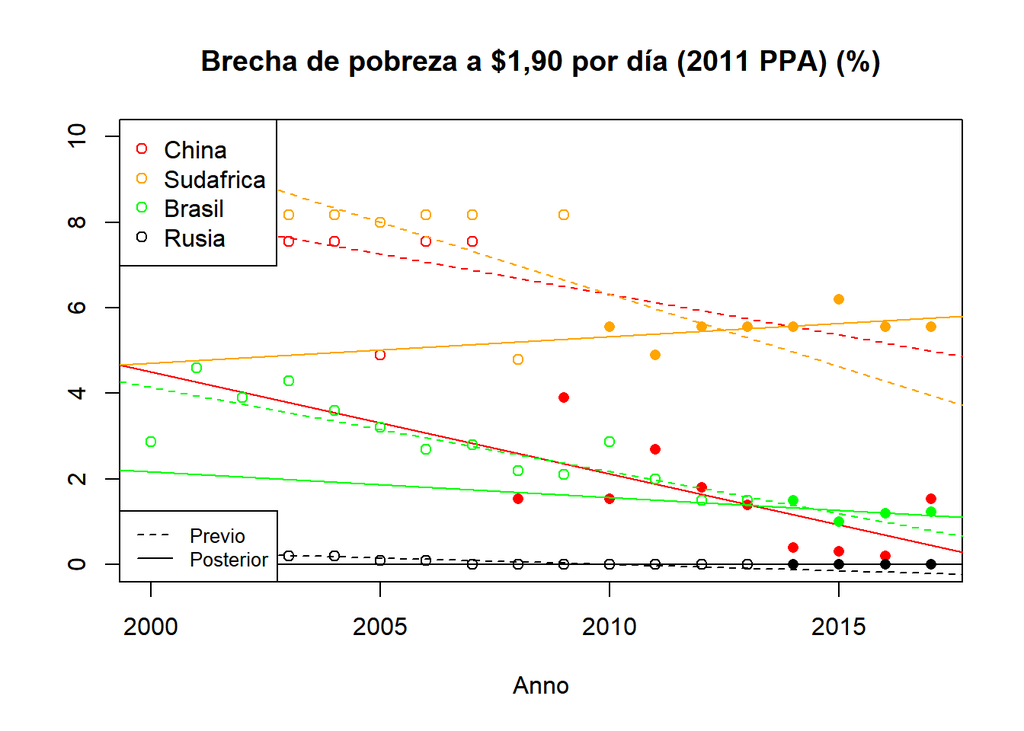

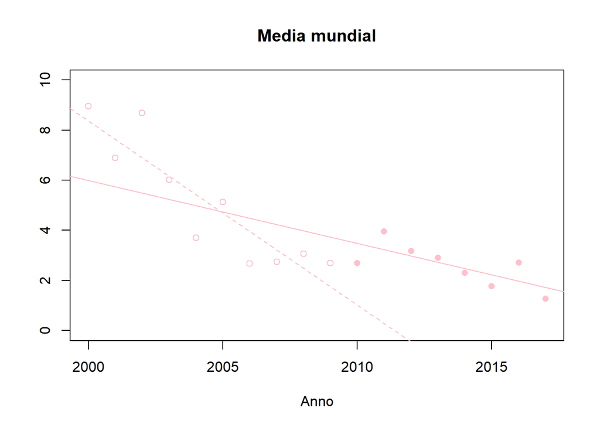

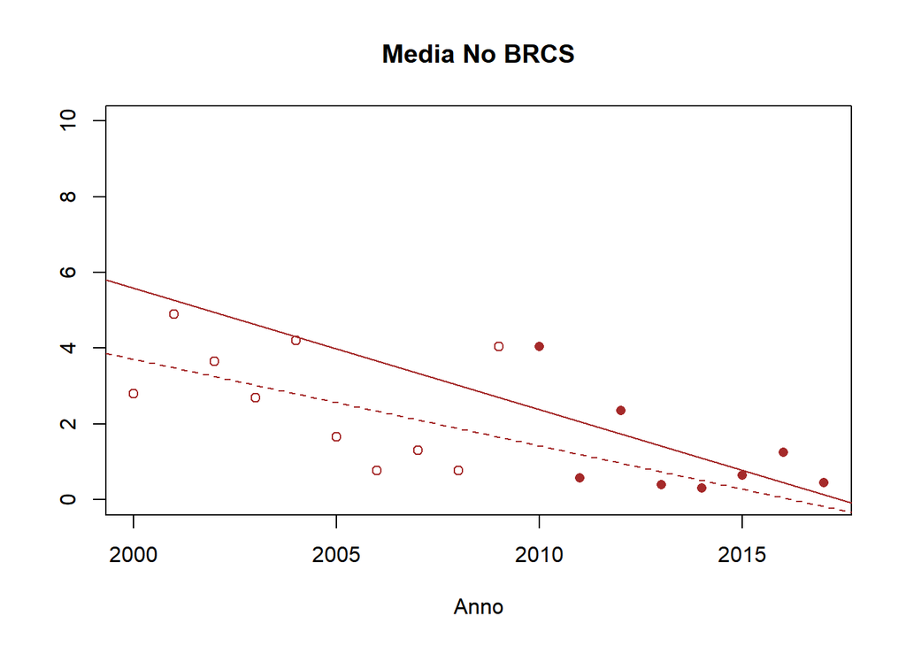

**Coeficientes de Correlacion - Brecha de pobreza a $1,90 por día (2011 PPA) (%)**

| China |  |  |
| --- | --- | --- |
| Tendencia | 2000 - 2008 | NEG |
| Correlación con Promedio mundial | 2000 - 2008 | 0.382 |
| Correlación con Promedio no BRCS | 2000 - 2008 | 0.368 |
| Tendencia | 2008 - 2017 | NEG |
| Correlación con Promedio mundial | 2008 - 2017 | 0.322 |
| Correlación con Promedio no BRCS | 2008 - 2017 | NA |
| Sudafrica |  |  |
| Tendencia | 2000 - 2010 | NEG |
| Correlación con Promedio mundial | 2000 - 2010 | 0.564 |
| Correlación con Promedio no BRCS | 2000 - 2010 | 0.319 |
| Tendencia | 2010 - 2017 | POS |
| Correlación con Promedio mundial | 2010 - 2017 | -0.164 |
| Correlación con Promedio no BRCS | 2010 - 2017 | NA |
| Brasil |  |  |
| Tendencia | 2000 - 2014 | NEG |
| Correlación con Promedio mundial | 2000 - 2014 | 0.672 |
| Correlación con Promedio no BRCS | 2000 - 2014 | 0.65 |
| Tendencia | 2014 - 2017 | NEG |
| Correlación con Promedio mundial | 2014 - 2017 | 0.573 |
| Correlación con Promedio no BRCS | 2014 - 2017 | NA |
| Rusia |  |  |
| Tendencia | 2000 - 2014 | NEG |
| Correlación con Promedio mundial | 2000 - 2014 | 0.768 |
| Correlación con Promedio no BRCS | 2000 - 2014 | 0.524 |
| Tendencia | 2014 - 2017 | — |
| Correlación con Promedio mundial | 2014 - 2017 | NA |
| Correlación con Promedio no BRCS | 2014 - 2017 | NA |

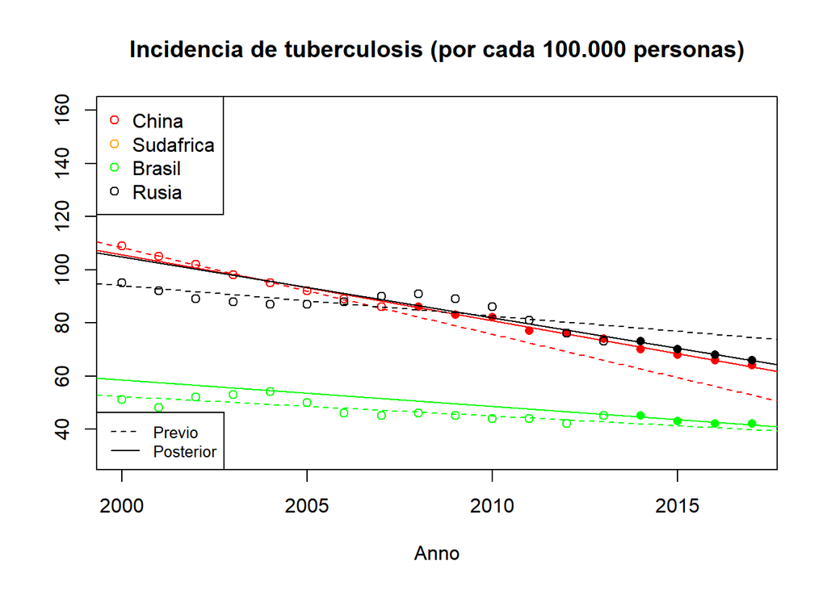

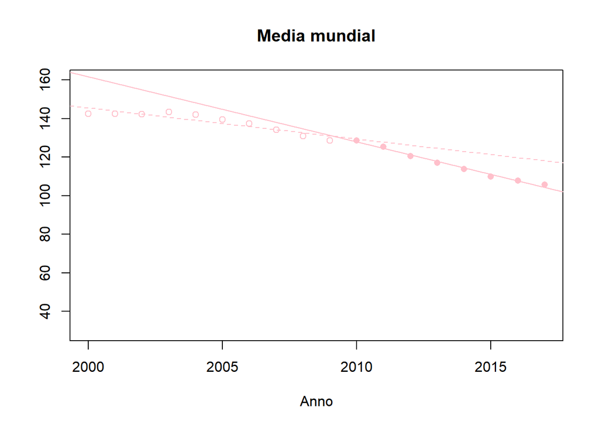

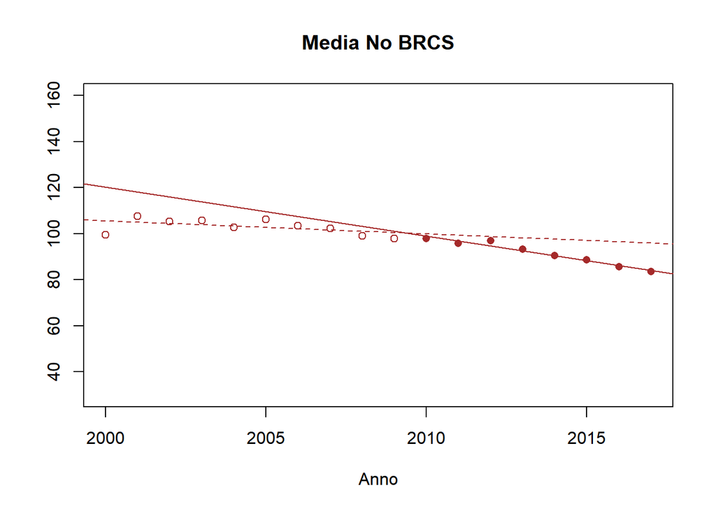

**Coeficientes de Correlacion - Incidencia de tuberculosis (por cada 100.000 personas)**

| China |  |  |
| --- | --- | --- |
| Tendencia | 2000 - 2008 | NEG |
| Correlación con Promedio mundial | 2000 - 2008 | 0.825 |
| Correlación con Promedio no BRCS | 2000 - 2008 | -0.024 |
| Tendencia | 2008 - 2017 | NEG |
| Correlación con Promedio mundial | 2008 - 2017 | 0.992 |
| Correlación con Promedio no BRCS | 2008 - 2017 | 0.976 |
| Sudafrica |  |  |
| Tendencia | 2000 - 2010 | POS |
| Correlación con Promedio mundial | 2000 - 2010 | -0.722 |
| Correlación con Promedio no BRCS | 2000 - 2010 | -0.262 |
| Tendencia | 2010 - 2017 | NEG |
| Correlación con Promedio mundial | 2010 - 2017 | 0.999 |
| Correlación con Promedio no BRCS | 2010 - 2017 | 0.967 |
| Brasil |  |  |
| Tendencia | 2000 - 2014 | NEG |
| Correlación con Promedio mundial | 2000 - 2014 | 0.827 |
| Correlación con Promedio no BRCS | 2000 - 2014 | 0.675 |
| Tendencia | 2014 - 2017 | NEG |
| Correlación con Promedio mundial | 2014 - 2017 | 0.94 |
| Correlación con Promedio no BRCS | 2014 - 2017 | 0.901 |
| Rusia |  |  |
| Tendencia | 2000 - 2014 | NEG |
| Correlación con Promedio mundial | 2000 - 2014 | 0.827 |
| Correlación con Promedio no BRCS | 2000 - 2014 | 0.698 |
| Tendencia | 2014 - 2017 | NEG |
| Correlación con Promedio mundial | 2014 - 2017 | 0.993 |
| Correlación con Promedio no BRCS | 2014 - 2017 | 0.993 |

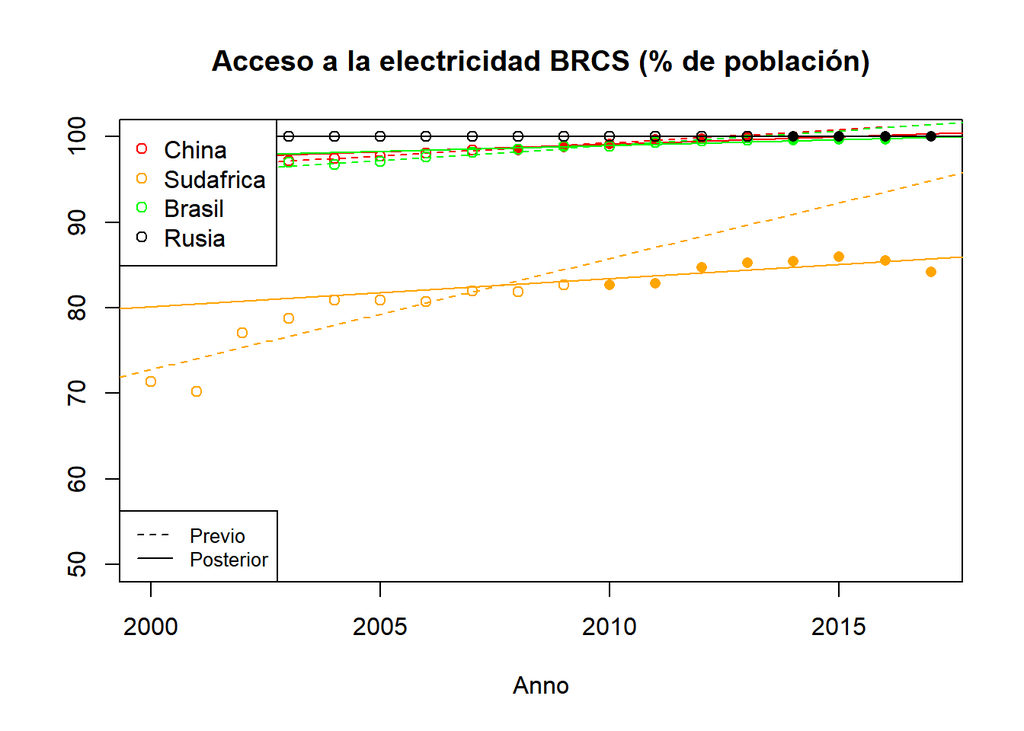

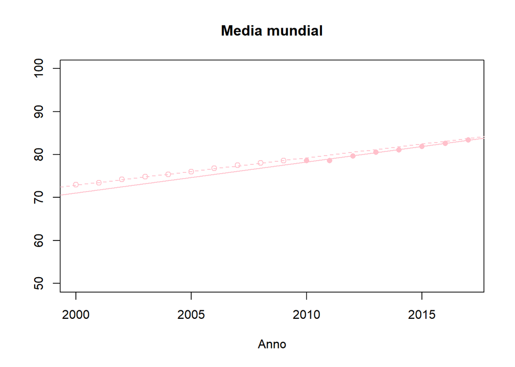